# {chronicle}

2021-06-24

## An R package for easy R Markdown reporting

```r
install.packages('chronicle')
```

This R package allows the user to create beautiful R Markdown reports in a wide gamut of outputs, without the need to be exposed to the code necessary to create each of its elements. chronicle is built on a layered paradigm, which will be familiar to any ggplot user.

### A quick demo

You can build R Markdown reports through the `add_*` family of functions, layering one below the previous one.

```r
library(chronicle)

demo_report <-
  add_text(text_title = "This is the output of a chronicle call",
           text = "Each element has been added through an add_* function.",
           title_level = 1) %>%
  add_table(table = head(iris),
            table_title = "A glimpse at the iris dataset",
            html_table_type = "kable",
            title_level = 1) %>%
  add_raincloud(dt = iris,
                value = "Sepal.Length",
                groups = "Species",
                raincloud_title = "Distribution of sepal length by species",
                title_level = 2) %>%
  add_scatterplot(dt = iris,
                  x = "Petal.Width",
                  y = "Petal.Length",
                  groups = "Species",
                  scatterplot_title = "Comparison of petal width and length",
                  title_level = 2)

render_report(report = demo_report,
              output_format = "rmdformats",
              filename = "quick_demo",
              title = "A quick chronicle demo",
              author = "You did this!",
              keep_rmd = TRUE)
```

```
## [1] TRUE
```

```
## [1] TRUE
```

You can see [the output of this call](https://pheymanss.github.io/chronicle-demos/quick_demo), and [a full showcase of all the elements supported by chronicle](https://pheymanss.github.io/chronicle-demos/showcase).

What happens behind these calls is that chronicle writes an R Markdown for you! you can see the report we’ve built by calling it through `cat()`

```r
demo_report
```

````
##
##
## # This is the output of a chronicle call
##
## Each element has been added through an add_* function.
##
## # A glimpse at the iris dataset
## ```{r, echo=FALSE, message=FALSE, warning=FALSE}
## knitr::kable(head(iris))
## ```
##
## ## Distribution of sepal length by species
## ```{r, echo=FALSE, message=FALSE, warning=FALSE, fig.width=params$figure_width, fig.height=params$figure_height}
## chronicle::make_raincloud(dt = iris,
##                           value = 'Sepal.Length',
##                           groups = 'Species',
##                           adjust = 0.5,
##                           include_boxplot = TRUE,
##                           include_mean = FALSE,
##                           include_median = TRUE,
##                           force_all_jitter_obs = FALSE,
##                           ggtheme = 'minimal',
##                           plot_palette = params$plot_palette,
##                           plot_palette_generator = params$plot_palette_generator,
##                           static = params$set_static)
## ```
##
## ## Comparison of petal width and length
## ```{r, echo=FALSE, message=FALSE, warning=FALSE, fig.width=params$figure_width, fig.height=params$figure_height}
## chronicle::make_scatterplot(dt = iris,
##                             x = 'Petal.Width',
##                             y = 'Petal.Length',
##                             groups = 'Species',
##                             plot_palette = params$plot_palette,
##                             plot_palette_generator = params$plot_palette_generator,
##                             static = params$set_static)
## ```
````

### The `make_*` family of functions

Every plot added with an `add_*` function will be built through its correpsonding `make_*` function. These functions take care of the heavy lifting, avoiding the cumbersome (albeit powerful) sintax of ggplot, plotly and other html widgets. The parameters of the make_functions are simple and intuitive specifications on how to make each plot, and they can be called independently and used in any instance where a ggplot or an html widget would fit.

[figure not shown]

chronicle bar plot

```r
make_barplot(dt = ggplot2::mpg,
             value = 'cty',
             bars = 'manufacturer',
             break_bars_by = 'drv',
             horizontal = TRUE,
             sort_by_value = TRUE,
             static = TRUE)
```

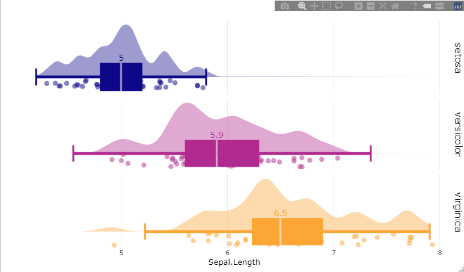

chronicle rain cloud plot

```r
make_raincloud(dt = iris,
             value = 'Sepal.Length',
             groups = 'Species')
```

### Rendering chronicle reports

Once the structure of the report has been defined, the rendering process is done by render_report(). This uses rmarkdonw::render() as a backend for rendering the report, which gives chronicle the capability to render the reports with full visibility to all objects in the global environment. This gives chronicle two of its main strengths:

1. You don’t need to include nor run all your data processing code again for a new report output. This means you can build several report recipes for different audiences out of the same data processing, with each one having their own report recipe.
2. It can render *several* output formats in a single call. For instance, it is possible to render the same content as [ioslides](https://garrettgman.github.io/rmarkdown/ioslides_presentation_format.html) for a presentation, as [tufte_html](https://rstudio.github.io/tufte/) for handouts and as rmdformats for a site upload.

Take our quick demo as an example, to render this as the three outputs mentioned previously, you only need to add that vector to the `output_format` parameter of `render_report()`

```r
render_report(report = demo_report,
              output_format = c("ioslides", "tufte_html", "rmdformats"),
              filename = "quick_demo",
              title = "A quick chronicle demo",
              author = "You did this!",
              keep_rmd = TRUE)
```

### The `report_columns()` function

chronicle also includes a function called report_columns(), that will create an entire chronicle report for a single dataset. It includes a comprehensive summary of the data through the skimr::skim() function, along with one plot for each column present in the data: bar plots for categorical variables and rain cloud plots for numerical variables. This gives you an immediate view of a dataset with a single line of code!

```r
report_columns(dt = palmerpenguins::penguins,
               by_column = 'species')
```

And you can see [the output of this call](https://pheymanss.github.io/chronicle-demos/report_columns)

### Supported formats

As of version 0.2.5, chronicle can output both static and dynamic outputs. Dynamic outputs refer to R Markdown formats that support html widgets, hence the elements added will be dynamic plots (plotly, dygraph, DT). For static outputs, these will roll back to ggplot and static table prints.

##### Dynamic outputs (html)

- bookdown
- github_document (you are reading one right now!)
- html_document
- [html_notebook](https://pheymanss.github.io/chronicle-demos/outputs/output_html_notebook.nb.html)
- ioslides
- prettydoc
- rmdformats (this is currently the default)
- slidy_presentation
- tufte_html

##### Static outputs

- pagedown
- pdf
- powerpoint_presentation
- rolldown
- tufte_handout
- word_document

Additionally, [{flexdashboard}](https://pkgs.rstudio.com/flexdashboard/) and [{xaringan}](https://slides.yihui.org/xaringan/#1) technically compile, but the layout is stiff in flexdashboard and altogether incorrect in xaringan. Also, [{rticles}](https://github.com/rstudio/rticles) support can technically be added, but that would involve a plethora of additional parameters for the header, and frankly, writing a journal article is not the intended use of the package

### Supported report elements

I highly encourage you to review the enitre showcase, words are not as adequate to describe each element. But for a quick glance, as of version 0.2.5 chronicle supports:

- Bar plots
- Box plots
- Code (optionally evaluated)
- Density plots
- Dygraphs
- Histograms
- Line plots
- Rain cloud plots
- Scatter plots
- Tables
- Texts
- Titles
- Violin plots